# Sweden

## Post-Harvest stream buffers

```python
import arcpy
arcpy.env.overwriteOutput = True
arcpy.env.parallelProcessingFactor = "100%"
```

Select harvest sites that were harvested within 5 years before being scanned with LiDAR. Some areas were scanned multiple times. The shapefile 'Y:/William/RIP_NATURE_2/Sweden/LiDAR/laserSquare_scandates.shp' contains a column named diff_years which indicates how many different years each tile was scanned with LiDAR. If the value is over 0 it means that it was scanned multiple years. Areas that were scanned multiple years were excluded to avoid confusion.

```python
swedish_lidar_original = 'Y:/William/RIP_NATURE_2/Sweden/LiDAR/laserSquare_scandates.shp'
scanned_one_year = arcpy.SelectLayerByAttribute_management(swedish_lidar_original, 'NEW_SELECTION', '"diff_years" = 0')
arcpy.CopyFeatures_management(scanned_one_year , 'Y:/William/RIP_NATURE_2/Sweden/LiDAR/swedish_lidar_selected.shp')
```

Output

Y:\William\RIP_NATURE_2\Sweden\LiDAR\swedish_lidar_selected.shp

Messages

Start Time: Monday, 18 October 2021 12:45:57  
Succeeded at Monday, 18 October 2021 12:46:07 (Elapsed Time: 10,46 seconds)

```python
sweden_tiles_index = 'Y:/William/RIP_NATURE_2/Sweden/LiDAR/swedish_lidar_selected.shp'
topographical_streams_sweden = 'Y:/William/RIP_NATURE_2/Sweden/hl_riks.shp'
sweden_harvest_sites = 'Y:/William/RIP_NATURE_2/Sweden/CC/Swedish_CC.shp'

## 2009
CC_5_years_before_2009 = arcpy.SelectLayerByAttribute_management(sweden_harvest_sites, 'NEW_SELECTION', '"HARVYR" > 2004 and "HARVYR" < 2009')
arcpy.CopyFeatures_management(CC_5_years_before_2009, 'Y:/William/RIP_NATURE_2/sweden/Post_harvest/CC_2004_2009.shp')

sweden_lidar_2009 = arcpy.SelectLayerByAttribute_management(sweden_tiles_index, 'NEW_SELECTION', '"final_year" = 2009')
arcpy.CopyFeatures_management(sweden_lidar_2009, 'Y:/William/RIP_NATURE_2/sweden/LiDAR_Years/sweden_lidar_2009.shp')

CC_2004_2009 = 'Y:/William/RIP_NATURE_2/sweden/Post_harvest/CC_2004_2009.shp'
lidar_2009 = 'Y:/William/RIP_NATURE_2/sweden/LiDAR_Years/sweden_lidar_2009.shp'

harvested_5_years_before_lidar_2009 = arcpy.SelectLayerByLocation_management(CC_2004_2009, 'INTERSECT', lidar_2009,'', 'NEW_SELECTION')
arcpy.CopyFeatures_management(harvested_5_years_before_lidar_2009, 'Y:/William/RIP_NATURE_2/sweden/CC_Year/CC_2004_to_2009_lidar_2009.shp')


## 2010
CC_5_years_before_2010 = arcpy.SelectLayerByAttribute_management(sweden_harvest_sites, 'NEW_SELECTION', '"HARVYR" > 2005 and "HARVYR" < 2010')
arcpy.CopyFeatures_management(CC_5_years_before_2010, 'Y:/William/RIP_NATURE_2/sweden/Post_harvest/CC_2005_2010.shp')

sweden_lidar_2010 = arcpy.SelectLayerByAttribute_management(sweden_tiles_index, 'NEW_SELECTION', '"final_year" = 2010')
arcpy.CopyFeatures_management(sweden_lidar_2010, 'Y:/William/RIP_NATURE_2/sweden/LiDAR_Years/sweden_lidar_2010.shp')

CC_2005_2010 = 'Y:/William/RIP_NATURE_2/sweden/Post_harvest/CC_2005_2010.shp'
lidar_2010 = 'Y:/William/RIP_NATURE_2/sweden/LiDAR_Years/sweden_lidar_2010.shp'

harvested_5_years_before_lidar_2010 = arcpy.SelectLayerByLocation_management(CC_2005_2010, 'INTERSECT', lidar_2010,'', 'NEW_SELECTION')
arcpy.CopyFeatures_management(harvested_5_years_before_lidar_2010, 'Y:/William/RIP_NATURE_2/sweden/CC_Year/CC_2005_to_2010_lidar_2010.shp')


## 2011
CC_5_years_before_2011 = arcpy.SelectLayerByAttribute_management(sweden_harvest_sites, 'NEW_SELECTION', '"HARVYR" > 2006 and "HARVYR" < 2011')
arcpy.CopyFeatures_management(CC_5_years_before_2011, 'Y:/William/RIP_NATURE_2/sweden/Post_harvest/CC_2006_2011.shp')

sweden_lidar_2011 = arcpy.SelectLayerByAttribute_management(sweden_tiles_index, 'NEW_SELECTION', '"final_year" = 2011')
arcpy.CopyFeatures_management(sweden_lidar_2011, 'Y:/William/RIP_NATURE_2/sweden/LiDAR_Years/sweden_lidar_2011.shp')

CC_2006_2011 = 'Y:/William/RIP_NATURE_2/sweden/Post_harvest/CC_2006_2011.shp'
lidar_2011 = 'Y:/William/RIP_NATURE_2/sweden/LiDAR_Years/sweden_lidar_2011.shp'

harvested_5_years_before_lidar_2011 = arcpy.SelectLayerByLocation_management(CC_2006_2011, 'INTERSECT', lidar_2011,'', 'NEW_SELECTION')
arcpy.CopyFeatures_management(harvested_5_years_before_lidar_2011, 'Y:/William/RIP_NATURE_2/sweden/CC_Year/CC_2006_to_2011_lidar_2011.shp')

sweden_tiles_index = 'Y:/William/RIP_NATURE_2/Sweden/LiDAR/swedish_lidar_selected.shp'
topographical_streams_sweden = 'Y:/William/RIP_NATURE_2/Sweden/hl_riks.shp'
sweden_harvest_sites = 'Y:/William/RIP_NATURE_2/Sweden/CC/Swedish_CC.shp'

## 2012
CC_5_years_before_2012 = arcpy.SelectLayerByAttribute_management(sweden_harvest_sites, 'NEW_SELECTION', '"HARVYR" > 2007 and "HARVYR" < 2012')
arcpy.CopyFeatures_management(CC_5_years_before_2012, 'Y:/William/RIP_NATURE_2/sweden/Post_harvest/CC_2007_2012.shp')

sweden_lidar_2012 = arcpy.SelectLayerByAttribute_management(sweden_tiles_index, 'NEW_SELECTION', '"final_year" = 2012')
arcpy.CopyFeatures_management(sweden_lidar_2012, 'Y:/William/RIP_NATURE_2/sweden/LiDAR_Years/sweden_lidar_2012.shp')

CC_2007_2012 = 'Y:/William/RIP_NATURE_2/sweden/Post_harvest/CC_2007_2012.shp'
lidar_2012 = 'Y:/William/RIP_NATURE_2/sweden/LiDAR_Years/sweden_lidar_2012.shp'

harvested_5_years_before_lidar_2012 = arcpy.SelectLayerByLocation_management(CC_2007_2012, 'INTERSECT', lidar_2012,'', 'NEW_SELECTION')
arcpy.CopyFeatures_management(harvested_5_years_before_lidar_2012, 'Y:/William/RIP_NATURE_2/sweden/CC_Year/CC_2007_to_2012_lidar_2012.shp')

sweden_tiles_index = 'Y:/William/RIP_NATURE_2/Sweden/LiDAR/swedish_lidar_selected.shp'
topographical_streams_sweden = 'Y:/William/RIP_NATURE_2/Sweden/hl_riks.shp'
sweden_harvest_sites = 'Y:/William/RIP_NATURE_2/Sweden/CC/Swedish_CC.shp'

## 2013
CC_5_years_before_2013 = arcpy.SelectLayerByAttribute_management(sweden_harvest_sites, 'NEW_SELECTION', '"HARVYR" > 2008 and "HARVYR" < 2013')
arcpy.CopyFeatures_management(CC_5_years_before_2013, 'Y:/William/RIP_NATURE_2/sweden/Post_harvest/CC_2008_2013.shp')

sweden_lidar_2013 = arcpy.SelectLayerByAttribute_management(sweden_tiles_index, 'NEW_SELECTION', '"final_year" = 2013')
arcpy.CopyFeatures_management(sweden_lidar_2013, 'Y:/William/RIP_NATURE_2/sweden/LiDAR_Years/sweden_lidar_2013.shp')

CC_2008_2013 = 'Y:/William/RIP_NATURE_2/sweden/Post_harvest/CC_2008_2013.shp'
lidar_2013 = 'Y:/William/RIP_NATURE_2/sweden/LiDAR_Years/sweden_lidar_2013.shp'

harvested_5_years_before_lidar_2013 = arcpy.SelectLayerByLocation_management(CC_2008_2013, 'INTERSECT', lidar_2013,'', 'NEW_SELECTION')
arcpy.CopyFeatures_management(harvested_5_years_before_lidar_2013, 'Y:/William/RIP_NATURE_2/sweden/CC_Year/CC_2008_to_2013_lidar_2013.shp')

sweden_tiles_index = 'Y:/William/RIP_NATURE_2/Sweden/LiDAR/swedish_lidar_selected.shp'
topographical_streams_sweden = 'Y:/William/RIP_NATURE_2/Sweden/hl_riks.shp'
sweden_harvest_sites = 'Y:/William/RIP_NATURE_2/Sweden/CC/Swedish_CC.shp'

## 2014
CC_5_years_before_2014 = arcpy.SelectLayerByAttribute_management(sweden_harvest_sites, 'NEW_SELECTION', '"HARVYR" > 2009 and "HARVYR" < 2014')
arcpy.CopyFeatures_management(CC_5_years_before_2014, 'Y:/William/RIP_NATURE_2/sweden/Post_harvest/CC_2009_2014.shp')

sweden_lidar_2014 = arcpy.SelectLayerByAttribute_management(sweden_tiles_index, 'NEW_SELECTION', '"final_year" = 2014')
arcpy.CopyFeatures_management(sweden_lidar_2014, 'Y:/William/RIP_NATURE_2/sweden/LiDAR_Years/sweden_lidar_2014.shp')

CC_2009_2014 = 'Y:/William/RIP_NATURE_2/sweden/Post_harvest/CC_2009_2014.shp'
lidar_2014 = 'Y:/William/RIP_NATURE_2/sweden/LiDAR_Years/sweden_lidar_2014.shp'

harvested_5_years_before_lidar_2014 = arcpy.SelectLayerByLocation_management(CC_2009_2014, 'INTERSECT', lidar_2014,'', 'NEW_SELECTION')
arcpy.CopyFeatures_management(harvested_5_years_before_lidar_2014, 'Y:/William/RIP_NATURE_2/sweden/CC_Year/CC_2009_to_2014_lidar_2014.shp')

sweden_tiles_index = 'Y:/William/RIP_NATURE_2/Sweden/LiDAR/swedish_lidar_selected.shp'
topographical_streams_sweden = 'Y:/William/RIP_NATURE_2/Sweden/hl_riks.shp'
sweden_harvest_sites = 'Y:/William/RIP_NATURE_2/Sweden/CC/Swedish_CC.shp'

## 2015
CC_5_years_before_2015 = arcpy.SelectLayerByAttribute_management(sweden_harvest_sites, 'NEW_SELECTION', '"HARVYR" > 2010 and "HARVYR" < 2015')
arcpy.CopyFeatures_management(CC_5_years_before_2015, 'Y:/William/RIP_NATURE_2/sweden/Post_harvest/CC_2010_2015.shp')

sweden_lidar_2015 = arcpy.SelectLayerByAttribute_management(sweden_tiles_index, 'NEW_SELECTION', '"final_year" = 2015')
arcpy.CopyFeatures_management(sweden_lidar_2015, 'Y:/William/RIP_NATURE_2/sweden/LiDAR_Years/sweden_lidar_2015.shp')

CC_2010_2015 = 'Y:/William/RIP_NATURE_2/sweden/Post_harvest/CC_2010_2015.shp'
lidar_2015 = 'Y:/William/RIP_NATURE_2/sweden/LiDAR_Years/sweden_lidar_2015.shp'

harvested_5_years_before_lidar_2015 = arcpy.SelectLayerByLocation_management(CC_2010_2015, 'INTERSECT', lidar_2015,'', 'NEW_SELECTION')
arcpy.CopyFeatures_management(harvested_5_years_before_lidar_2015, 'Y:/William/RIP_NATURE_2/sweden/CC_Year/CC_2010_to_2015_lidar_2015.shp')

sweden_tiles_index = 'Y:/William/RIP_NATURE_2/Sweden/LiDAR/swedish_lidar_selected.shp'
topographical_streams_sweden = 'Y:/William/RIP_NATURE_2/Sweden/hl_riks.shp'
sweden_harvest_sites = 'Y:/William/RIP_NATURE_2/Sweden/CC/Swedish_CC.shp'

## 2016
CC_5_years_before_2016 = arcpy.SelectLayerByAttribute_management(sweden_harvest_sites, 'NEW_SELECTION', '"HARVYR" > 2011 and "HARVYR" < 2016')
arcpy.CopyFeatures_management(CC_5_years_before_2016, 'Y:/William/RIP_NATURE_2/sweden/Post_harvest/CC_2011_2016.shp')

sweden_lidar_2016 = arcpy.SelectLayerByAttribute_management(sweden_tiles_index, 'NEW_SELECTION', '"final_year" = 2016')
arcpy.CopyFeatures_management(sweden_lidar_2016, 'Y:/William/RIP_NATURE_2/sweden/LiDAR_Years/sweden_lidar_2016.shp')

CC_2011_2016 = 'Y:/William/RIP_NATURE_2/sweden/Post_harvest/CC_2011_2016.shp'
lidar_2016 = 'Y:/William/RIP_NATURE_2/sweden/LiDAR_Years/sweden_lidar_2016.shp'

harvested_5_years_before_lidar_2016 = arcpy.SelectLayerByLocation_management(CC_2011_2016, 'INTERSECT', lidar_2016,'', 'NEW_SELECTION')
arcpy.CopyFeatures_management(harvested_5_years_before_lidar_2016, 'Y:/William/RIP_NATURE_2/sweden/CC_Year/CC_2011_to_2016_lidar_2016.shp')

# Merge
inputs = 'Y:/William/RIP_NATURE_2/Sweden/CC_Year/CC_2004_to_2009_lidar_2009.shp','Y:/William/RIP_NATURE_2/Sweden/CC_Year/CC_2005_to_2010_lidar_2010.shp','Y:/William/RIP_NATURE_2/Sweden/CC_Year/CC_2006_to_2011_lidar_2011.shp','Y:/William/RIP_NATURE_2/Sweden/CC_Year/CC_2007_to_2012_lidar_2012shp','Y:/William/RIP_NATURE_2/Sweden/CC_Year/CC_2008_to_2013_lidar_2013.shp','Y:/William/RIP_NATURE_2/Sweden/CC_Year/CC_2009_to_2014_lidar_2014.shp','Y:/William/RIP_NATURE_2/Sweden/CC_Year/CC_2010_to_2015_lidar_2015.shp','Y:/William/RIP_NATURE_2/Sweden/CC_Year/CC_2011_to_2016_lidar_2016.shp'
output = 'Y:/William/RIP_NATURE_2/sweden/sweden_harvest_before_LiDAR_merged.shp'
arcpy.management.Merge(inputs, output)
```

```python
# Merge
inputs = 'Y:/William/RIP_NATURE_2/Sweden/CC_Year/CC_2004_to_2009_lidar_2009.shp','Y:/William/RIP_NATURE_2/Sweden/CC_Year/CC_2005_to_2010_lidar_2010.shp','Y:/William/RIP_NATURE_2/Sweden/CC_Year/CC_2006_to_2011_lidar_2011.shp','Y:/William/RIP_NATURE_2/Sweden/CC_Year/CC_2007_to_2012_lidar_2012.shp','Y:/William/RIP_NATURE_2/Sweden/CC_Year/CC_2008_to_2013_lidar_2013.shp','Y:/William/RIP_NATURE_2/Sweden/CC_Year/CC_2009_to_2014_lidar_2014.shp','Y:/William/RIP_NATURE_2/Sweden/CC_Year/CC_2010_to_2015_lidar_2015.shp','Y:/William/RIP_NATURE_2/Sweden/CC_Year/CC_2011_to_2016_lidar_2016.shp'
output = 'Y:/William/RIP_NATURE_2/sweden/sweden_harvest_before_LiDAR_merged.shp'
arcpy.management.Merge(inputs, output)
```

Output

Y:\William\RIP_NATURE_2\Sweden\sweden_harvest_before_LiDAR_merged.shp

Messages

Start Time: Monday, 18 October 2021 15:56:00  
Succeeded at Monday, 18 October 2021 15:56:38 (Elapsed Time: 37,57 seconds)

```python
sweden_post_harvest_year = pd.DataFrame.spatial.from_featureclass('Y:/William/RIP_NATURE_2/sweden/sweden_harvest_before_LiDAR_merged.shp')
sweden_post_harvest_year.head()
```

|  | FID | OBJECTID | Lannr | Lan | Kommunnr | Kommun | Arendear | Beteckn | Avverktyp | Skogstyp | AnmaldHa | SkogsodlHa | Natforha | Avvdatum | Kalladatum | Kallaareal | Forebild | Efterbild | Arealha | Text_years | Field | HARVYR | SHAPE |
| --- | --- | --- | --- | --- | --- | --- | --- | --- | --- | --- | --- | --- | --- | --- | --- | --- | --- | --- | --- | --- | --- | --- | --- |
| 0 | 0 | 793720 | 25 | Norrbottens län | 82 | Boden | 2005 | A 76024-2005 | Föryngringsavverkning | Normal skog | 3.0 | 3.0 | 0.0 | 2007-06-30 | SKS annan uppgift | Kopia på anmälan |  |  | 3.0 |  | 0 | 2007 | {"rings": [[[790441.0119792615, 7364640.224304... |
| 1 | 1 | 1072960 | 25 | Norrbottens län | 18 | Övertorneå | 2000 | A 36447-2000 | Föryngringsavverkning | Normal skog | 3.0 | 0.0 | 3.0 | 2005-01-01 | SKS annan uppgift | Kopia på anmälan |  |  | 2.6 |  | 0 | 2005 | {"rings": [[[890228.7765828292, 7423633.862563... |
| 2 | 2 | 1075765 | 25 | Norrbottens län | 23 | Gällivare | 2000 | A 39397-2000 | Föryngringsavverkning | Svårföryngrad | 25.6 | 25.6 | 0.0 | 2005-01-01 | SKS annan uppgift | Kopia på anmälan |  |  | 25.6 |  | 0 | 2005 | {"rings": [[[805487.5875797652, 7392215.535603... |
| 3 | 3 | 1075774 | 25 | Norrbottens län | 23 | Gällivare | 2000 | A 40059-2000 | Föryngringsavverkning | Svårföryngrad | 3.3 | 3.3 | 0.0 | 2005-01-01 | SKS annan uppgift | Kopia på anmälan |  |  | 3.3 |  | 0 | 2005 | {"rings": [[[815094.077818857, 7400092.2955589... |
| 4 | 4 | 1075775 | 25 | Norrbottens län | 23 | Gällivare | 2000 | A 40060-2000 | Föryngringsavverkning | Svårföryngrad | 4.1 | 0.0 | 4.1 | 2005-01-01 | SKS annan uppgift | Kopia på anmälan |  |  | 4.1 |  | 0 | 2005 | {"rings": [[[814997.8626982409, 7399954.059189... |

We were only interested in harvest sites that were near a stream. We buffered the selected harvested sites with 30 m. These buffered harveste sites where then used to intersect with the topographical stream network

```python
arcpy.Buffer_analysis('Y:/William/RIP_NATURE_2/sweden/sweden_harvest_before_LiDAR_merged.shp', 'Y:/William/RIP_NATURE_2/Sweden/Buffer_CC_after_LiDAR/Buffered_post_harvest_scanne_CCs.shp', '30 Meters')
```

Output

Y:\William\RIP_NATURE_2\Sweden\Buffer_CC_after_LiDAR\Buffered_post_harvest_scanne_CCs.shp

Messages

Start Time: Monday, 18 October 2021 16:03:19  
Succeeded at Monday, 18 October 2021 16:44:53 (Elapsed Time: 41 minutes 34 seconds)

```python
infeatures = (topographical_streams_sweden, 'Y:/William/RIP_NATURE_2/Sweden/Buffer_CC_after_LiDAR/Buffered_post_harvest_scanne_CCs.shp')
intersected_streams = 'Y:/William/RIP_NATURE_2/Sweden/Intersected_Streams.shp'
arcpy.Intersect_analysis(infeatures, intersected_streams)
```

Output

Y:\William\RIP_NATURE_2\Sweden\Intersected_Streams.shp

Messages

Start Time: Tuesday, 19 October 2021 09:33:28  
Reading Features...  
Assembling Features...  
Succeeded at Tuesday, 19 October 2021 09:39:03 (Elapsed Time: 5 minutes 35 seconds)

Select and export streams longer than 20m. Stream sections had to be at least >20m because boreal canopy gaps can be naturally 0.1 ha, so we wanted to avoid these potentially natural gaps

```python
intersected_streams = 'Y:/William/RIP_NATURE_2/Sweden/Intersected_Streams.shp'

arcpy.AddGeometryAttributes_management(intersected_streams, 'LENGTH', 'METERS')
attribute_selected = arcpy.SelectLayerByAttribute_management(intersected_streams, 'NEW_SELECTION',
                                        '"LENGTH" > 20')
arcpy.CopyFeatures_management(attribute_selected, 'Y:/William/RIP_NATURE_2/Sweden/stream_segments_longer_than_20m.shp')
```

Output

Y:\William\RIP_NATURE_2\Sweden\stream_segments_longer_than_20m.shp

Messages

Start Time: Tuesday, 19 October 2021 10:01:18  
Succeeded at Tuesday, 19 October 2021 10:02:02 (Elapsed Time: 43,49 seconds)

Next the stream segments were buffered on both sides by 20 m and dissolved seperatly.

```python
# Streams
stream_segments_over_20m = 'Y:/William/RIP_NATURE_2/Sweden/stream_segments_longer_than_20m.shp'

# buffer outputs
buffer_left_side = 'Y:/William/RIP_NATURE_2/Sweden/Buffer_CC_after_LiDAR/Buffer_left_harvested_sites.shp'
buffer_right_side = 'Y:/William/RIP_NATURE_2/Sweden/Buffer_CC_after_LiDAR/Buffer_right_harvested_sites.shp'

buffer_distance = '20 Meters'
sideType_left = 'LEFT'
sideType_right = 'RIGHT'
endType = 'FLAT'
dissolveType = 'NONE'
dissolveField = 'NONE'


# Buffer Left
arcpy.Buffer_analysis(stream_segments_over_20m, buffer_left_side, buffer_distance, sideType_left, endType,
                      dissolveType)

# Buffer Right
arcpy.Buffer_analysis(stream_segments_over_20m, buffer_right_side, buffer_distance, sideType_right, endType,
                      dissolveType)
buffer_left_side = 'Y:/William/RIP_NATURE_2/Sweden/Buffer_CC_after_LiDAR/Buffer_left_harvested_sites.shp'
buffer_right_side = 'Y:/William/RIP_NATURE_2/Sweden/Buffer_CC_after_LiDAR/Buffer_right_harvested_sites.shp'

dissolve_left = 'Y:/William/RIP_NATURE_2/Sweden/dissolve/dissolve_left.shp'
dissolve_right = 'Y:/William/RIP_NATURE_2/Sweden/dissolve/dissolve_right.shp'

# Dissolve and copy left buffers
arcpy.Dissolve_management(buffer_left_side, dissolve_left,"", "", "SINGLE_PART", "UNSPLIT_LINES")

# Dissolve and copy Right buffers
arcpy.Dissolve_management(buffer_right_side, dissolve_right,"", "", "SINGLE_PART", "UNSPLIT_LINES")
```

Output

Y:\William\RIP_NATURE_2\Sweden\dissolve\dissolve_right.shp

Messages

Start Time: Tuesday, 19 October 2021 11:59:08  
Dissolving...  
Succeeded at Tuesday, 19 October 2021 11:59:26 (Elapsed Time: 17,19 seconds)

Select and merge buffer polygons within 10 m of a harvesting site that were harvested before being lidar scanned.

```python
dissolve_left = 'Y:/William/RIP_NATURE_2/Sweden/dissolve/dissolve_left.shp'
dissolve_right = 'Y:/William/RIP_NATURE_2/Sweden/dissolve/dissolve_right.shp'

harvestsites =  'Y:/William/RIP_NATURE_2/Sweden/CC_Before_LiDAR_within30m_of_stream/CC_BeforeLiDAR_wthin30mof_Stream.shp'

copy_left = 'Y:/William/RIP_NATURE_2/Sweden/Dissolved_buffers_within_10m_of_stream_lidar_after_harvest/within_10m_of_CC_left_buffer.shp'
copy_right = 'Y:/William/RIP_NATURE_2/Sweden/Dissolved_buffers_within_10m_of_stream_lidar_after_harvest/within_10m_of_CC_right_buffer.shp'

selection_type = 'NEW_SELECTION'

# Left
select_Left = arcpy.SelectLayerByLocation_management(dissolve_left, 'WITHIN_A_DISTANCE', harvestsites, '10 Meters', selection_type)
arcpy.CopyFeatures_management(select_Left, copy_left)
# Right
select_Right = arcpy.SelectLayerByLocation_management(dissolve_right, 'WITHIN_A_DISTANCE', harvestsites, '10 Meters', selection_type)
arcpy.CopyFeatures_management(select_Right, copy_right)

# Dissolved and selected buffers
Dissolved_left_side_within_10m_of_harvest_sites = 'Y:/William/RIP_NATURE_2/Sweden/Dissolved_buffers_within_10m_of_stream_lidar_after_harvest/CC_within_10mof_left_buffer.shp'
Dissolved_right_right_within_10m_of_harvest_sites = 'Y:/William/RIP_NATURE_2/Sweden/Dissolved_buffers_within_10m_of_stream_lidar_after_harvest/CC_within_10mof_right_buffer.shp'

# Merged buffers
merged_buffer_within_10m_of_CC = 'Y:/William/RIP_NATURE_2/Sweden/Dissolved_buffers_within_10m_of_stream_lidar_after_harvest/merged_buffer_within_10m_of_CC.shp'
arcpy.Merge_management([Dissolved_left_side_within_10m_of_harvest_sites, Dissolved_right_right_within_10m_of_harvest_sites], merged_buffer_within_10m_of_CC)
```

Output

Y:\William\RIP_NATURE_2\Sweden\Dissolved_buffers_within_10m_of_stream_lidar_after_harvest\merged_buffer_within_10m_of_CC.shp

Messages

Start Time: Tuesday, 19 October 2021 12:18:33  
Succeeded at Tuesday, 19 October 2021 12:18:50 (Elapsed Time: 16,96 seconds)

Dissolve merged buffers

```python
# Merged polygons
merged_buffer_within_10m_of_CC = 'Y:/William/RIP_NATURE_2/Sweden/Dissolved_buffers_within_10m_of_stream_lidar_after_harvest/merged_buffer_within_10m_of_CC.shp'
# Dissolved polygons
Dissolved_buffer_within_10m_of_CC = 'Y:/William/RIP_NATURE_2/Sweden/Dissolved_buffers_within_10m_of_stream_lidar_after_harvest/merged_buffer_within_10m_of_CC_dissolved.shp'

arcpy.Dissolve_management(merged_buffer_within_10m_of_CC, Dissolved_buffer_within_10m_of_CC,"", "", "SINGLE_PART", "DISSOLVE_LINES")
```

Output

Y:\William\RIP_NATURE_2\Sweden\Dissolved_buffers_within_10m_of_stream_lidar_after_harvest\merged_buffer_within_10m_of_CC_dissolved.shp

Messages

Start Time: Tuesday, 19 October 2021 12:32:20  
Dissolving...  
Succeeded at Tuesday, 19 October 2021 12:32:49 (Elapsed Time: 28,24 seconds)

Finally the Swedish forest mask was used to clip the buffer zones to make sure that only forest land were included

```python
Dissolved_buffer_within_10m_of_CC = 'Y:/William/RIP_NATURE_2/Sweden/Dissolved_buffers_within_10m_of_stream_lidar_after_harvest/merged_buffer_within_10m_of_CC_dissolved.shp'
Swedis_forest_land = 'Y:/William/RIP_NATURE_2/Sweden/ForestryLand.shp'
Post_harvest_buffer_zones = 'Y:/William/RIP_NATURE_2/Sweden/buffers_post_harvest.shp'
arcpy.Clip_analysis(Dissolved_buffer_within_10m_of_CC , Swedis_forest_land, Post_harvest_buffer_zones)
```

Output

Y:\William\RIP_NATURE_2\Sweden\buffers_post_harvest.shp

Messages

Start Time: Tuesday, 19 October 2021 12:35:04  
Reading Features...  
Assembling Features...  
Succeeded at Tuesday, 19 October 2021 12:39:56 (Elapsed Time: 4 minutes 51 seconds)

```python
nr_sites_post_harvest = arcpy.GetCount_management(Post_harvest_buffer_zones)
print(nr_sites_post_harvest)
```

```
70550
```

Extract canopy cover statistics within the buffer zones using zonal statistcs as table

```python
import arcpy
from arcpy.sa import *
Post_harvest_buffer_zones = 'Y:/William/RIP_NATURE_2/Sweden/buffers_post_harvest.shp'

# Set the local variables
inZoneData = Post_harvest_buffer_zones
zoneField = 'FID'
inValueRaster = 'Y:/William/RIP_NATURE_2/Sweden/Tradhojdsraster/Mosaic_Hela_1_0.tif'
outTable = 'Y:/William/RIP_NATURE_2/Sweden/ZonalStatistics/sweden_post_harvest_buffers.dbf'

# Execute ZonalStatisticsAsTable
ZonalStatisticsAsTable(inZoneData, zoneField, inValueRaster,
                                 outTable, "NODATA", "SUM", "")
```

## Pre-Harvest stream buffers

To relate the post harvest canopy densities I also need pre harvest canopy densities. To this end we selected sites that were harvested after being scanned with LiDAR. This means that they were in their unharvested state during the LiDAR scan.

```python
sweden_tiles_index = 'Y:/William/RIP_NATURE_2/Sweden/LiDAR/swedish_lidar_selected.shp'
sweden_harvest_sites = 'Y:/William/RIP_NATURE_2/Sweden/CC/Swedish_CC.shp'

#The earliest scan was done 2009.
#### 2009 ####
# CC after 2009
CC_after_2009 = arcpy.SelectLayerByAttribute_management(sweden_harvest_sites, 'NEW_SELECTION', '"HARVYR" > 2009')
arcpy.CopyFeatures_management(CC_after_2009, 'Y:/William/RIP_NATURE_2/sweden/Post_harvest/CC_after_2009.shp')
# LiDAR 2015
sweden_lidar_2009 = arcpy.SelectLayerByAttribute_management(sweden_tiles_index, 'NEW_SELECTION', '"final_year" = 2009')
arcpy.CopyFeatures_management(sweden_lidar_2009, 'Y:/William/RIP_NATURE_2/sweden/LiDAR_Years/sweden_lidar_2009')

CC_after_2009 = 'Y:/William/RIP_NATURE_2/sweden/Post_harvest/CC_after_2009.shp'
sweden_lidar_2009 = 'Y:/William/RIP_NATURE_2/sweden/LiDAR_Years/sweden_lidar_2009.shp'

CC_after_lidar_2009 = arcpy.SelectLayerByLocation_management(CC_after_2009, 'INTERSECT', sweden_lidar_2009,'', 'NEW_SELECTION')
arcpy.CopyFeatures_management(CC_after_lidar_2009, 'Y:/William/RIP_NATURE_2/sweden/Pre_harvest/CC_after_lidar_2009.shp')

# CC after 2010
CC_after_2010 = arcpy.SelectLayerByAttribute_management(sweden_harvest_sites, 'NEW_SELECTION', '"HARVYR" > 2010')
arcpy.CopyFeatures_management(CC_after_2010, 'Y:/William/RIP_NATURE_2/sweden/Post_harvest/CC_after_2010.shp')
# LiDAR 2010
sweden_lidar_2010 = arcpy.SelectLayerByAttribute_management(sweden_tiles_index, 'NEW_SELECTION', '"final_year" = 2010')
arcpy.CopyFeatures_management(sweden_lidar_2010, 'Y:/William/RIP_NATURE_2/sweden/LiDAR_Years/sweden_lidar_2010')

CC_after_2010 = 'Y:/William/RIP_NATURE_2/sweden/Post_harvest/CC_after_2010.shp'
sweden_lidar_2010 = 'Y:/William/RIP_NATURE_2/sweden/LiDAR_Years/sweden_lidar_2010.shp'

CC_after_lidar_2010 = arcpy.SelectLayerByLocation_management(CC_after_2010, 'INTERSECT', sweden_lidar_2010,'', 'NEW_SELECTION')
arcpy.CopyFeatures_management(CC_after_lidar_2010, 'Y:/William/RIP_NATURE_2/sweden/Pre_harvest/CC_after_lidar_2010.shp')

# CC after 2011
CC_after_2011 = arcpy.SelectLayerByAttribute_management(sweden_harvest_sites, 'NEW_SELECTION', '"HARVYR" > 2011')
arcpy.CopyFeatures_management(CC_after_2011, 'Y:/William/RIP_NATURE_2/sweden/Post_harvest/CC_after_2011.shp')
# LiDAR 2011
sweden_lidar_2011 = arcpy.SelectLayerByAttribute_management(sweden_tiles_index, 'NEW_SELECTION', '"final_year" = 2011')
arcpy.CopyFeatures_management(sweden_lidar_2011, 'Y:/William/RIP_NATURE_2/sweden/LiDAR_Years/sweden_lidar_2011')

CC_after_2011 = 'Y:/William/RIP_NATURE_2/sweden/Post_harvest/CC_after_2011.shp'
sweden_lidar_2011 = 'Y:/William/RIP_NATURE_2/sweden/LiDAR_Years/sweden_lidar_2011.shp'

CC_after_lidar_2011 = arcpy.SelectLayerByLocation_management(CC_after_2011, 'INTERSECT', sweden_lidar_2011,'', 'NEW_SELECTION')
arcpy.CopyFeatures_management(CC_after_lidar_2011, 'Y:/William/RIP_NATURE_2/sweden/Pre_harvest/CC_after_lidar_2011.shp')

# CC after 2012
CC_after_2012 = arcpy.SelectLayerByAttribute_management(sweden_harvest_sites, 'NEW_SELECTION', '"HARVYR" > 2012')
arcpy.CopyFeatures_management(CC_after_2012, 'Y:/William/RIP_NATURE_2/sweden/Post_harvest/CC_after_2012.shp')
# LiDAR 2012
sweden_lidar_2012 = arcpy.SelectLayerByAttribute_management(sweden_tiles_index, 'NEW_SELECTION', '"final_year" = 2012')
arcpy.CopyFeatures_management(sweden_lidar_2012, 'Y:/William/RIP_NATURE_2/sweden/LiDAR_Years/sweden_lidar_2012')

CC_after_2012 = 'Y:/William/RIP_NATURE_2/sweden/Post_harvest/CC_after_2012.shp'
sweden_lidar_2012 = 'Y:/William/RIP_NATURE_2/sweden/LiDAR_Years/sweden_lidar_2012.shp'

CC_after_lidar_2012 = arcpy.SelectLayerByLocation_management(CC_after_2012, 'INTERSECT', sweden_lidar_2012,'', 'NEW_SELECTION')
arcpy.CopyFeatures_management(CC_after_lidar_2012, 'Y:/William/RIP_NATURE_2/sweden/Pre_harvest/CC_after_lidar_2012.shp')

# CC after 2013
CC_after_2013 = arcpy.SelectLayerByAttribute_management(sweden_harvest_sites, 'NEW_SELECTION', '"HARVYR" > 2013')
arcpy.CopyFeatures_management(CC_after_2013, 'Y:/William/RIP_NATURE_2/sweden/Post_harvest/CC_after_2013.shp')
# LiDAR 2013
sweden_lidar_2013 = arcpy.SelectLayerByAttribute_management(sweden_tiles_index, 'NEW_SELECTION', '"final_year" = 2013')
arcpy.CopyFeatures_management(sweden_lidar_2013, 'Y:/William/RIP_NATURE_2/sweden/LiDAR_Years/sweden_lidar_2013')

CC_after_2013 = 'Y:/William/RIP_NATURE_2/sweden/Post_harvest/CC_after_2013.shp'
sweden_lidar_2013 = 'Y:/William/RIP_NATURE_2/sweden/LiDAR_Years/sweden_lidar_2013.shp'

CC_after_lidar_2013 = arcpy.SelectLayerByLocation_management(CC_after_2013, 'INTERSECT', sweden_lidar_2013,'', 'NEW_SELECTION')
arcpy.CopyFeatures_management(CC_after_lidar_2013, 'Y:/William/RIP_NATURE_2/sweden/Pre_harvest/CC_after_lidar_2013.shp')
# CC after 2014
CC_after_2014 = arcpy.SelectLayerByAttribute_management(sweden_harvest_sites, 'NEW_SELECTION', '"HARVYR" > 2014')
arcpy.CopyFeatures_management(CC_after_2014, 'Y:/William/RIP_NATURE_2/sweden/Post_harvest/CC_after_2014.shp')
# LiDAR 2014
sweden_lidar_2014 = arcpy.SelectLayerByAttribute_management(sweden_tiles_index, 'NEW_SELECTION', '"final_year" = 2014')
arcpy.CopyFeatures_management(sweden_lidar_2014, 'Y:/William/RIP_NATURE_2/sweden/LiDAR_Years/sweden_lidar_2014')

CC_after_2014 = 'Y:/William/RIP_NATURE_2/sweden/Post_harvest/CC_after_2014.shp'
sweden_lidar_2014 = 'Y:/William/RIP_NATURE_2/sweden/LiDAR_Years/sweden_lidar_2014.shp'

CC_after_lidar_2014 = arcpy.SelectLayerByLocation_management(CC_after_2014, 'INTERSECT', sweden_lidar_2014,'', 'NEW_SELECTION')
arcpy.CopyFeatures_management(CC_after_lidar_2014, 'Y:/William/RIP_NATURE_2/sweden/Pre_harvest/CC_after_lidar_2014.shp')

# CC after 2015
CC_after_2015 = arcpy.SelectLayerByAttribute_management(sweden_harvest_sites, 'NEW_SELECTION', '"HARVYR" > 2015')
arcpy.CopyFeatures_management(CC_after_2015, 'Y:/William/RIP_NATURE_2/sweden/Post_harvest/CC_after_2015.shp')
# LiDAR 2015
sweden_lidar_2015 = arcpy.SelectLayerByAttribute_management(sweden_tiles_index, 'NEW_SELECTION', '"final_year" = 2015')
arcpy.CopyFeatures_management(sweden_lidar_2015, 'Y:/William/RIP_NATURE_2/sweden/LiDAR_Years/sweden_lidar_2015')

CC_after_2015 = 'Y:/William/RIP_NATURE_2/sweden/Post_harvest/CC_after_2015.shp'
sweden_lidar_2015 = 'Y:/William/RIP_NATURE_2/sweden/LiDAR_Years/sweden_lidar_2015.shp'

CC_after_lidar_2015 = arcpy.SelectLayerByLocation_management(CC_after_2015, 'INTERSECT', sweden_lidar_2015,'', 'NEW_SELECTION')
arcpy.CopyFeatures_management(CC_after_lidar_2015, 'Y:/William/RIP_NATURE_2/sweden/Pre_harvest/CC_after_lidar_2015.shp')

# CC after 2016
CC_after_2016 = arcpy.SelectLayerByAttribute_management(sweden_harvest_sites, 'NEW_SELECTION', '"HARVYR" > 2016')
arcpy.CopyFeatures_management(CC_after_2016, 'Y:/William/RIP_NATURE_2/sweden/Post_harvest/CC_after_2016.shp')
# LiDAR 2016
sweden_lidar_2016 = arcpy.SelectLayerByAttribute_management(sweden_tiles_index, 'NEW_SELECTION', '"final_year" = 2016')
arcpy.CopyFeatures_management(sweden_lidar_2016, 'Y:/William/RIP_NATURE_2/sweden/LiDAR_Years/sweden_lidar_2016')

CC_after_2016 = 'Y:/William/RIP_NATURE_2/sweden/Post_harvest/CC_after_2016.shp'
sweden_lidar_2016 = 'Y:/William/RIP_NATURE_2/sweden/LiDAR_Years/sweden_lidar_2016.shp'

CC_after_lidar_2016 = arcpy.SelectLayerByLocation_management(CC_after_2016, 'INTERSECT', sweden_lidar_2016,'', 'NEW_SELECTION')
arcpy.CopyFeatures_management(CC_after_lidar_2016, 'Y:/William/RIP_NATURE_2/sweden/Pre_harvest/CC_after_lidar_2016.shp')
```

Output

Messages

Start Time: Tuesday, 19 October 2021 13:53:55  
Succeeded at Tuesday, 19 October 2021 13:54:37 (Elapsed Time: 42,31 seconds)

```python
# Merge reference sites
CC_after_lidar_2009 = 'Y:/William/RIP_NATURE_2/sweden/Pre_harvest/CC_after_lidar_2009.shp'
CC_after_lidar_2010 = 'Y:/William/RIP_NATURE_2/sweden/Pre_harvest/CC_after_lidar_2010.shp'
CC_after_lidar_2011 = 'Y:/William/RIP_NATURE_2/sweden/Pre_harvest/CC_after_lidar_2011.shp'
CC_after_lidar_2012 = 'Y:/William/RIP_NATURE_2/sweden/Pre_harvest/CC_after_lidar_2012.shp'
CC_after_lidar_2013 = 'Y:/William/RIP_NATURE_2/sweden/Pre_harvest/CC_after_lidar_2013.shp'
CC_after_lidar_2014 = 'Y:/William/RIP_NATURE_2/sweden/Pre_harvest/CC_after_lidar_2014.shp'
CC_after_lidar_2015 = 'Y:/William/RIP_NATURE_2/sweden/Pre_harvest/CC_after_lidar_2015.shp'
CC_after_lidar_2016 = 'Y:/William/RIP_NATURE_2/sweden/Pre_harvest/CC_after_lidar_2016.shp'

merge_sweden_reference_sites = 'Y:/William/RIP_NATURE_2/sweden/Pre_harvest/merge_sweden_reference_sites.shp'
arcpy.Merge_management([CC_after_lidar_2009,CC_after_lidar_2010,CC_after_lidar_2011,CC_after_lidar_2012,CC_after_lidar_2013,CC_after_lidar_2014,CC_after_lidar_2015, CC_after_lidar_2016], merge_sweden_reference_sites)
```

Output

Y:\William\RIP_NATURE_2\Sweden\Pre_harvest\merge_sweden_reference_sites.shp

Messages

Start Time: Wednesday, 20 October 2021 10:26:03  
Succeeded at Wednesday, 20 October 2021 10:27:07 (Elapsed Time: 1 minutes 3 seconds)

Streams from the Swedish property map were intersected with unharvested sites

```python
topographical_streams_sweden = 'Y:/William/RIP_NATURE_2/Sweden/hl_riks.shp'
Relevant_pre_harvest_sites = 'Y:/William/RIP_NATURE_2/sweden/Pre_harvest/merge_sweden_reference_sites.shp'
Intersected_reference_streams = 'Y:/William/RIP_NATURE_2/Sweden/Reference_sites/streams_intersect_CC.shp'

infeatures = (topographical_streams_sweden, Relevant_pre_harvest_sites)
arcpy.Intersect_analysis(infeatures, Intersected_reference_streams)
```

Output

Y:\William\RIP_NATURE_2\Sweden\Reference_sites\streams_intersect_CC.shp

Messages

Start Time: Wednesday, 20 October 2021 11:04:08  
Reading Features...  
Assembling Features...  
Succeeded at Wednesday, 20 October 2021 11:09:13 (Elapsed Time: 5 minutes 5 seconds)

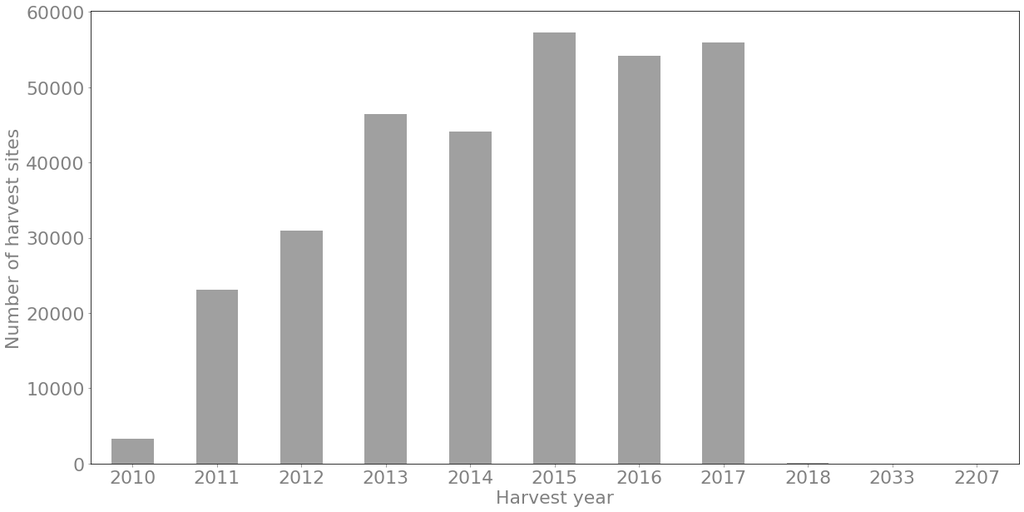

```python
import pandas as pd
import matplotlib as mpl
from arcgis.features import SpatialDataFrame
sweden_pre_harvest = 'Y:/William/RIP_NATURE_2/sweden/Pre_harvest/merge_sweden_reference_sites.shp'
sweden_pre_harvest_year = pd.DataFrame.spatial.from_featureclass(sweden_pre_harvest)

import matplotlib.pyplot as plt
sweden_pre_harvest_year = sweden_pre_harvest_year['HARVYR'].value_counts().sort_index(ascending=True)


COLOR = 'grey'
mpl.rcParams['text.color'] = COLOR
mpl.rcParams['axes.labelcolor'] = COLOR
mpl.rcParams['xtick.color'] = COLOR
mpl.rcParams['ytick.color'] = COLOR

plt.rcParams.update({'font.size': 22})

fig = sweden_pre_harvest_year.plot(kind='bar',
                        alpha=0.75,
                        figsize=(20,10),
                        color=COLOR,
                        rot='0')
plt.ylabel("Number of harvest sites")
plt.xlabel("Harvest year")

plt.show()
```

Stream segments over 20 m were buffered by 20 m and intersected with unharvested sites

```python
Intersected_reference_streams = 'Y:/William/RIP_NATURE_2/Sweden/Reference_sites/streams_intersect_CC.shp'
Intersected_reference_streams_over_20m = 'Y:/William/RIP_NATURE_2/Sweden/Reference_sites/streams_intersect_CC_over20m.shp'

# Add lenght
arcpy.AddGeometryAttributes_management(Intersected_reference_streams, 'LENGTH', 'METERS')

# Select and copy segments over 20 m
attribute_selected_ref = arcpy.SelectLayerByAttribute_management(Intersected_reference_streams, 'NEW_SELECTION', '"LENGTH" > 20')
arcpy.CopyFeatures_management(attribute_selected_ref, Intersected_reference_streams_over_20m)

Intersected_reference_streams_over_20m = 'Y:/William/RIP_NATURE_2/Sweden/Reference_sites/streams_intersect_CC_over20m.shp'
Intersected_reference_streams_over_20m_buffered_by_20m = 'Y:/William/RIP_NATURE_2/Sweden/Reference_sites/streams_intersect_CC_over20m_buffered_20m.shp'

Relevant_pre_harvest_sites = 'Y:/William/RIP_NATURE_2/Sweden/Reference_sites/CC_2011_to_2016_LiDAR_2009_or_2010.shp'
Intersect_buffered_stream_segments_with_unharvested_sites = 'Y:/William/RIP_NATURE_2/Sweden/Reference_sites/Buffered_reference_streams_intersect_CC.shp'

# Buffer stream segments by 20 m
arcpy.Buffer_analysis(Intersected_reference_streams_over_20m, Intersected_reference_streams_over_20m_buffered_by_20m, '20 Meters')
# Intersect Buffered stream segments with unharvest sites
infeatures = (Intersected_reference_streams_over_20m_buffered_by_20m, Relevant_pre_harvest_sites)
arcpy.Intersect_analysis(infeatures, Intersect_buffered_stream_segments_with_unharvested_sites)
```

Output

Y:\William\RIP_NATURE_2\Sweden\Reference_sites\Buffered_reference_streams_intersect_CC.shp

Messages

Start Time: Wednesday, 20 October 2021 12:03:13  
Reading Features...  
Assembling Features...  
Succeeded at Wednesday, 20 October 2021 12:04:15 (Elapsed Time: 1 minutes 1 seconds)

Finally the reference buffers were dissolved based on harvest site ID.

```python
Intersect_buffered_stream_segments_with_unharvested_sites = 'Y:/William/RIP_NATURE_2/Sweden/Reference_sites/Buffered_reference_streams_intersect_CC.shp'
Dissolve_reference_buffer_zones = 'Y:/William/RIP_NATURE_2/Sweden/Reference_sites/Buffered_reference_streams_intersect_CC_dissolve_by_CC.shp'
dissolveFields = ["FID_CC_201"]
arcpy.Dissolve_management(Intersect_buffered_stream_segments_with_unharvested_sites, Dissolve_reference_buffer_zones, dissolveFields, "", "SINGLE_PART", "DISSOLVE_LINES")
```

Output

Y:\William\RIP_NATURE_2\Sweden\Reference_sites\Buffered_reference_streams_intersect_CC_dissolve_by_CC.shp

Messages

Start Time: Wednesday, 20 October 2021 12:07:33  
Sorting Attributes...  
Dissolving...  
Succeeded at Wednesday, 20 October 2021 12:10:35 (Elapsed Time: 3 minutes 1 seconds)

Extract canopy cover within reference buffer polygons

```python
import arcpy
from arcpy.sa import *
Post_harvest_buffer_zones = 'Y:/William/RIP_NATURE_2/Sweden/Reference_sites/Buffered_reference_streams_intersect_CC_dissolve_by_CC.shp'

# Set the local variables
inZoneData = Post_harvest_buffer_zones
zoneField = 'FID'
inValueRaster = 'Y:/William/RIP_NATURE_2/Sweden/Tradhojdsraster/Mosaic_Hela_1_0.tif'
outTable = 'Y:/William/RIP_NATURE_2/Sweden/ZonalStatistics/sweden_pre_harvest_buffers.dbf'

# Execute ZonalStatisticsAsTable
ZonalStatisticsAsTable(inZoneData, zoneField, inValueRaster,
                                 outTable, "NODATA", "SUM", "")
```

Sweden harvest sites and reference sites

```python
# Harvestes sites
Harvested = 'Y:/William/RIP_NATURE_2/Sweden/buffers_post_harvest.shp'
print(arcpy.GetCount_management(Harvested),'Harvested buffers')


# Reference sites
Reference = 'Y:/William/RIP_NATURE_2/Sweden/Reference_sites/Buffered_reference_streams_intersect_CC_dissolve_by_CC.shp'
print(arcpy.GetCount_management(Reference),'Reference unharvested buffers')
```

```
70550 Harvested buffers
21249 Reference unharvested buffers
```

# Finland

## Post Harvest

Post harvest means that the harvest sites were scanned with LiDAR within 5 years after being harvested. For example a site harvested between 2003 and 2008 would be in its harvested condition during a lidar scan that was conducted 2008. The shapefile 'Y:/William/RIP_NATURE_2/Finland/LIDAR/LiDARScanYear.shp' contains the column "final_year" that indicates when a sites was scanned with LiDAR. The file 'Y:/RIP_NATURE/Finland/Finland/NewclearcutsFromAntti/CC_declaration25112020.gdb/CC_declaration25112020.gdb/MKI_CC' contains harvest polygons and a column "year" that indicate which year the sites were harvested. Harvests between 2003 and 2018 were used.

```python
import arcpy
arcpy.env.overwriteOutput = True
arcpy.env.parallelProcessingFactor = "100%"
```

```python
finland_tiles_index = 'Y:/William/RIP_NATURE_2/Finland/LIDAR/LiDARScanYear.shp'
finland_harvest_sites = 'Y:/RIP_NATURE/Finland/Finland/NewclearcutsFromAntti/CC_declaration25112020.gdb/CC_declaration25112020.gdb/MKI_CC'

## 2008
CC_5_years_before_2008 = arcpy.SelectLayerByAttribute_management(finland_harvest_sites, 'NEW_SELECTION', '"year" > 2003 and "year" < 2008')
arcpy.CopyFeatures_management(CC_5_years_before_2008, 'Y:/William/RIP_NATURE_2/finland/Post_harvest/CC_2003_2008.shp')

finland_lidar_2008 = arcpy.SelectLayerByAttribute_management(finland_tiles_index, 'NEW_SELECTION', '"final_year" = 2008')
arcpy.CopyFeatures_management(finland_lidar_2008, 'Y:/William/RIP_NATURE_2/finland/LiDAR_Years/finland_lidar_2008.shp')

CC_2003_2008 = 'Y:/William/RIP_NATURE_2/finland/Post_harvest/CC_2003_2008.shp'
lidar_2008 = 'Y:/William/RIP_NATURE_2/finland/LiDAR_Years/finland_lidar_2008.shp'

harvested_5_years_before_lidar_2008 = arcpy.SelectLayerByLocation_management(CC_2003_2008, 'INTERSECT', lidar_2008,'', 'NEW_SELECTION')
arcpy.CopyFeatures_management(harvested_5_years_before_lidar_2008, 'Y:/William/RIP_NATURE_2/Finland/CC_Year/CC_2003_to_2008_lidar_2008.shp')

## 2009
CC_5_years_before_2009 = arcpy.SelectLayerByAttribute_management(finland_harvest_sites, 'NEW_SELECTION', '"year" > 2004 and "year" < 2009')
arcpy.CopyFeatures_management(CC_5_years_before_2009, 'Y:/William/RIP_NATURE_2/finland/Post_harvest/CC_2004_2009.shp')

finland_lidar_2009 = arcpy.SelectLayerByAttribute_management(finland_tiles_index, 'NEW_SELECTION', '"final_year" = 2009')
arcpy.CopyFeatures_management(finland_lidar_2009, 'Y:/William/RIP_NATURE_2/finland/LiDAR_Years/finland_lidar_2009.shp')

CC_2004_2009 = 'Y:/William/RIP_NATURE_2/finland/Post_harvest/CC_2004_2009.shp'
lidar_2009 = 'Y:/William/RIP_NATURE_2/finland/LiDAR_Years/finland_lidar_2009.shp'

harvested_5_years_before_lidar_2009 = arcpy.SelectLayerByLocation_management(CC_2004_2009, 'INTERSECT', lidar_2009,'', 'NEW_SELECTION')
arcpy.CopyFeatures_management(harvested_5_years_before_lidar_2009, 'Y:/William/RIP_NATURE_2/Finland/CC_Year/CC_2004_to_2009_lidar_2009.shp')

## 2010
CC_5_years_before_2010 = arcpy.SelectLayerByAttribute_management(finland_harvest_sites, 'NEW_SELECTION', '"year" > 2005 and "year" < 2010')
arcpy.CopyFeatures_management(CC_5_years_before_2010, 'Y:/William/RIP_NATURE_2/finland/Post_harvest/CC_2005_2010.shp')

finland_lidar_2010 = arcpy.SelectLayerByAttribute_management(finland_tiles_index, 'NEW_SELECTION', '"final_year" = 2010')
arcpy.CopyFeatures_management(finland_lidar_2010, 'Y:/William/RIP_NATURE_2/finland/LiDAR_Years/finland_lidar_2010.shp')

CC_2005_2010 = 'Y:/William/RIP_NATURE_2/finland/Post_harvest/CC_2005_2010.shp'
lidar_2010 = 'Y:/William/RIP_NATURE_2/finland/LiDAR_Years/finland_lidar_2010.shp'

harvested_5_years_before_lidar_2010 = arcpy.SelectLayerByLocation_management(CC_2005_2010, 'INTERSECT', lidar_2010,'', 'NEW_SELECTION')
arcpy.CopyFeatures_management(harvested_5_years_before_lidar_2010, 'Y:/William/RIP_NATURE_2/Finland/CC_Year/CC_2005_to_2010_lidar_2010.shp')

## 2011
CC_5_years_before_2011 = arcpy.SelectLayerByAttribute_management(finland_harvest_sites, 'NEW_SELECTION', '"year" > 2006 and "year" < 2011')
arcpy.CopyFeatures_management(CC_5_years_before_2011, 'Y:/William/RIP_NATURE_2/finland/Post_harvest/CC_2006_2011.shp')

finland_lidar_2011 = arcpy.SelectLayerByAttribute_management(finland_tiles_index, 'NEW_SELECTION', '"final_year" = 2011')
arcpy.CopyFeatures_management(finland_lidar_2011, 'Y:/William/RIP_NATURE_2/finland/LiDAR_Years/finland_lidar_2011.shp')

CC_2006_2011 = 'Y:/William/RIP_NATURE_2/finland/Post_harvest/CC_2006_2011.shp'
lidar_2011 = 'Y:/William/RIP_NATURE_2/finland/LiDAR_Years/finland_lidar_2011.shp'

harvested_5_years_before_lidar_2011 = arcpy.SelectLayerByLocation_management(CC_2006_2011, 'INTERSECT', lidar_2011,'', 'NEW_SELECTION')
arcpy.CopyFeatures_management(harvested_5_years_before_lidar_2011, 'Y:/William/RIP_NATURE_2/Finland/CC_Year/CC_2006_to_2011_lidar_2011.shp')

## 2012
CC_5_years_before_2012 = arcpy.SelectLayerByAttribute_management(finland_harvest_sites, 'NEW_SELECTION', '"year" > 2007 and "year" < 2012')
arcpy.CopyFeatures_management(CC_5_years_before_2012, 'Y:/William/RIP_NATURE_2/finland/Post_harvest/CC_2007_2012.shp')

finland_lidar_2012 = arcpy.SelectLayerByAttribute_management(finland_tiles_index, 'NEW_SELECTION', '"final_year" = 2012')
arcpy.CopyFeatures_management(finland_lidar_2012, 'Y:/William/RIP_NATURE_2/finland/LiDAR_Years/finland_lidar_2012.shp')

CC_2007_2012 = 'Y:/William/RIP_NATURE_2/finland/Post_harvest/CC_2007_2012.shp'
lidar_2012 = 'Y:/William/RIP_NATURE_2/finland/LiDAR_Years/finland_lidar_2012.shp'

harvested_5_years_before_lidar_2012 = arcpy.SelectLayerByLocation_management(CC_2007_2012, 'INTERSECT', lidar_2012,'', 'NEW_SELECTION')
arcpy.CopyFeatures_management(harvested_5_years_before_lidar_2012, 'Y:/William/RIP_NATURE_2/Finland/CC_Year/CC_2007_to_2012_lidar_2012.shp')

## 2013
CC_5_years_before_2013 = arcpy.SelectLayerByAttribute_management(finland_harvest_sites, 'NEW_SELECTION', '"year" > 2008 and "year" < 2013')
arcpy.CopyFeatures_management(CC_5_years_before_2013, 'Y:/William/RIP_NATURE_2/finland/Post_harvest/CC_2008_2013.shp')

finland_lidar_2013 = arcpy.SelectLayerByAttribute_management(finland_tiles_index, 'NEW_SELECTION', '"final_year" = 2013')
arcpy.CopyFeatures_management(finland_lidar_2013, 'Y:/William/RIP_NATURE_2/finland/LiDAR_Years/finland_lidar_2013.shp')

CC_2008_2013 = 'Y:/William/RIP_NATURE_2/finland/Post_harvest/CC_2008_2013.shp'
lidar_2013 = 'Y:/William/RIP_NATURE_2/finland/LiDAR_Years/finland_lidar_2013.shp'

harvested_5_years_before_lidar_2013 = arcpy.SelectLayerByLocation_management(CC_2008_2013, 'INTERSECT', lidar_2013,'', 'NEW_SELECTION')
arcpy.CopyFeatures_management(harvested_5_years_before_lidar_2013, 'Y:/William/RIP_NATURE_2/Finland/CC_Year/CC_2008_to_2013_lidar_2013.shp')

## 2014
CC_5_years_before_2014 = arcpy.SelectLayerByAttribute_management(finland_harvest_sites, 'NEW_SELECTION', '"year" > 2009 and "year" < 2014')
arcpy.CopyFeatures_management(CC_5_years_before_2014, 'Y:/William/RIP_NATURE_2/finland/Post_harvest/CC_2009_2014.shp')

finland_lidar_2014 = arcpy.SelectLayerByAttribute_management(finland_tiles_index, 'NEW_SELECTION', '"final_year" = 2014')
arcpy.CopyFeatures_management(finland_lidar_2014, 'Y:/William/RIP_NATURE_2/finland/LiDAR_Years/finland_lidar_2014.shp')

CC_2009_2014 = 'Y:/William/RIP_NATURE_2/finland/Post_harvest/CC_2009_2014.shp'
lidar_2014 = 'Y:/William/RIP_NATURE_2/finland/LiDAR_Years/finland_lidar_2014.shp'

harvested_5_years_before_lidar_2014 = arcpy.SelectLayerByLocation_management(CC_2009_2014, 'INTERSECT', lidar_2014,'', 'NEW_SELECTION')
arcpy.CopyFeatures_management(harvested_5_years_before_lidar_2014, 'Y:/William/RIP_NATURE_2/Finland/CC_Year/CC_2009_to_2014_lidar_2014.shp')

## 2015
CC_5_years_before_2015 = arcpy.SelectLayerByAttribute_management(finland_harvest_sites, 'NEW_SELECTION', '"year" > 2010 and "year" < 2015')
arcpy.CopyFeatures_management(CC_5_years_before_2015, 'Y:/William/RIP_NATURE_2/finland/Post_harvest/CC_2010_2015.shp')

finland_lidar_2015 = arcpy.SelectLayerByAttribute_management(finland_tiles_index, 'NEW_SELECTION', '"final_year" = 2015')
arcpy.CopyFeatures_management(finland_lidar_2015, 'Y:/William/RIP_NATURE_2/finland/LiDAR_Years/finland_lidar_2015.shp')

CC_2010_2015 = 'Y:/William/RIP_NATURE_2/finland/Post_harvest/CC_2010_2015.shp'
lidar_2015 = 'Y:/William/RIP_NATURE_2/finland/LiDAR_Years/finland_lidar_2015.shp'

harvested_5_years_before_lidar_2015 = arcpy.SelectLayerByLocation_management(CC_2010_2015, 'INTERSECT', lidar_2015,'', 'NEW_SELECTION')
arcpy.CopyFeatures_management(harvested_5_years_before_lidar_2015, 'Y:/William/RIP_NATURE_2/Finland/CC_Year/CC_2010_to_2015_lidar_2015.shp')

## 2016
CC_5_years_before_2016 = arcpy.SelectLayerByAttribute_management(finland_harvest_sites, 'NEW_SELECTION', '"year" > 2011 and "year" < 2016')
arcpy.CopyFeatures_management(CC_5_years_before_2016, 'Y:/William/RIP_NATURE_2/finland/Post_harvest/CC_2011_2016.shp')

finland_lidar_2016 = arcpy.SelectLayerByAttribute_management(finland_tiles_index, 'NEW_SELECTION', '"final_year" = 2016')
arcpy.CopyFeatures_management(finland_lidar_2016, 'Y:/William/RIP_NATURE_2/finland/LiDAR_Years/finland_lidar_2016.shp')

CC_2011_2016 = 'Y:/William/RIP_NATURE_2/finland/Post_harvest/CC_2011_2016.shp'
lidar_2016 = 'Y:/William/RIP_NATURE_2/finland/LiDAR_Years/finland_lidar_2016.shp'

harvested_5_years_before_lidar_2016 = arcpy.SelectLayerByLocation_management(CC_2011_2016, 'INTERSECT', lidar_2016,'', 'NEW_SELECTION')
arcpy.CopyFeatures_management(harvested_5_years_before_lidar_2016, 'Y:/William/RIP_NATURE_2/Finland/CC_Year/CC_2011_to_2016_lidar_2016.shp')

## 2017
CC_5_years_before_2017 = arcpy.SelectLayerByAttribute_management(finland_harvest_sites, 'NEW_SELECTION', '"year" > 2012 and "year" < 2017')
arcpy.CopyFeatures_management(CC_5_years_before_2017, 'Y:/William/RIP_NATURE_2/finland/Post_harvest/CC_2012_2017.shp')

finland_lidar_2017 = arcpy.SelectLayerByAttribute_management(finland_tiles_index, 'NEW_SELECTION', '"final_year" = 2017')
arcpy.CopyFeatures_management(finland_lidar_2017, 'Y:/William/RIP_NATURE_2/finland/LiDAR_Years/finland_lidar_2017.shp')

CC_2012_2017 = 'Y:/William/RIP_NATURE_2/finland/Post_harvest/CC_2012_2017.shp'
lidar_2017 = 'Y:/William/RIP_NATURE_2/finland/LiDAR_Years/finland_lidar_2017.shp'

harvested_5_years_before_lidar_2017 = arcpy.SelectLayerByLocation_management(CC_2012_2017, 'INTERSECT', lidar_2017,'', 'NEW_SELECTION')
arcpy.CopyFeatures_management(harvested_5_years_before_lidar_2017, 'Y:/William/RIP_NATURE_2/Finland/CC_Year/CC_2012_to_2017_lidar_2017.shp')

## 2018
CC_5_years_before_2018 = arcpy.SelectLayerByAttribute_management(finland_harvest_sites, 'NEW_SELECTION', '"year" > 2013 and "year" < 2018')
arcpy.CopyFeatures_management(CC_5_years_before_2018, 'Y:/William/RIP_NATURE_2/finland/Post_harvest/CC_2013_2018.shp')

finland_lidar_2018 = arcpy.SelectLayerByAttribute_management(finland_tiles_index, 'NEW_SELECTION', '"final_year" = 2018')
arcpy.CopyFeatures_management(finland_lidar_2018, 'Y:/William/RIP_NATURE_2/finland/LiDAR_Years/finland_lidar_2018.shp')

CC_2013_2018 = 'Y:/William/RIP_NATURE_2/finland/Post_harvest/CC_2013_2018.shp'
lidar_2018 = 'Y:/William/RIP_NATURE_2/finland/LiDAR_Years/finland_lidar_2018.shp'

harvested_5_years_before_lidar_2018 = arcpy.SelectLayerByLocation_management(CC_2013_2018, 'INTERSECT', lidar_2018,'', 'NEW_SELECTION')
arcpy.CopyFeatures_management(harvested_5_years_before_lidar_2018, 'Y:/William/RIP_NATURE_2/Finland/CC_Year/CC_2013_to_2018_lidar_2018.shp')
```

Output

Y:\William\RIP_NATURE_2\Finland\CC_Year\CC_2013_to_2018_lidar_2018.shp

Messages

Start Time: Wednesday, 20 October 2021 17:29:06  
Succeeded at Wednesday, 20 October 2021 17:29:08 (Elapsed Time: 1,86 seconds)

All selected harvest sites were merged into one shapefile for further processing.

```python
# Merge
CC_2003_to_2008_lidar_2008 = 'Y:/William/RIP_NATURE_2/Finland/CC_Year/CC_2003_to_2008_lidar_2008.shp'
CC_2004_to_2009_lidar_2009 = 'Y:/William/RIP_NATURE_2/Finland/CC_Year/CC_2004_to_2009_lidar_2009.shp'
CC_2005_to_2010_lidar_2010 = 'Y:/William/RIP_NATURE_2/Finland/CC_Year/CC_2005_to_2010_lidar_2010.shp'
CC_2006_to_2011_lidar_2011 = 'Y:/William/RIP_NATURE_2/Finland/CC_Year/CC_2006_to_2011_lidar_2011.shp'
CC_2007_to_2012_lidar_2012 = 'Y:/William/RIP_NATURE_2/Finland/CC_Year/CC_2007_to_2012_lidar_2012.shp'
CC_2008_to_2013_lidar_2013 = 'Y:/William/RIP_NATURE_2/Finland/CC_Year/CC_2008_to_2013_lidar_2013.shp'
CC_2009_to_2014_lidar_2014 = 'Y:/William/RIP_NATURE_2/Finland/CC_Year/CC_2009_to_2014_lidar_2014.shp'
CC_2010_to_2015_lidar_2015 = 'Y:/William/RIP_NATURE_2/Finland/CC_Year/CC_2010_to_2015_lidar_2015.shp'
CC_2011_to_2016_lidar_2016 = 'Y:/William/RIP_NATURE_2/Finland/CC_Year/CC_2011_to_2016_lidar_2016.shp'
CC_2012_to_2017_lidar_2017 = 'Y:/William/RIP_NATURE_2/Finland/CC_Year/CC_2012_to_2017_lidar_2017.shp'
CC_2013_to_2018_lidar_2018 = 'Y:/William/RIP_NATURE_2/Finland/CC_Year/CC_2013_to_2018_lidar_2018.shp'

inputs = CC_2003_to_2008_lidar_2008, CC_2004_to_2009_lidar_2009, CC_2005_to_2010_lidar_2010,CC_2006_to_2011_lidar_2011,CC_2007_to_2012_lidar_2012,CC_2008_to_2013_lidar_2013,CC_2009_to_2014_lidar_2014,CC_2010_to_2015_lidar_2015,CC_2011_to_2016_lidar_2016,CC_2012_to_2017_lidar_2017,CC_2013_to_2018_lidar_2018

output = 'Y:/William/RIP_NATURE_2/finland/finland_harvest_before_LiDAR_merged.shp'
arcpy.management.Merge(inputs, output)
```

Output

Y:\William\RIP_NATURE_2\Finland\finland_harvest_before_LiDAR_merged.shp

Messages

Start Time: Friday, 22 October 2021 11:21:42  
Succeeded at Friday, 22 October 2021 11:22:45 (Elapsed Time: 1 minutes 2 seconds)

The selected harvest sites were intersected with streams selected from this stream dataset: https://ckan.ymparisto.fi/dataset/%7BE15CD0B3-3934-4ABC-BF23-A8C622FA6A57%7D

The stream were selected based on the upper catchment area of stream endpoints. "ValuLuokka" 1 and 2 represents small streams.

```python
Original_Streams_Finland = 'Y:/William/RIP_NATURE_2/Finland/streams/Uoma10.shp'
selected_streams_Finland =  'Y:/William/RIP_NATURE_2/Finland/streams/Uoma1and2.shp'

attribute_selected_ref = arcpy.SelectLayerByAttribute_management(Original_Streams_Finland, 'NEW_SELECTION', '"ValuLuokka" <= 2')
arcpy.CopyFeatures_management(attribute_selected_ref, selected_streams_Finland)
```

Output

Y:\William\RIP_NATURE_2\Finland\streams\Uoma1and2.shp

Messages

Start Time: Monday, 20 September 2021 18:35:39  
Succeeded at Monday, 20 September 2021 18:35:46 (Elapsed Time: 6,55 seconds)

harvest polygons within 30 m of a stream were selected and buffered by 30 m. These buffered harvest sites will be used later to intersect stream segments.

```python
import arcpy
Post_harvest_sites_Finland = 'Y:/William/RIP_NATURE_2/finland/finland_harvest_before_LiDAR_merged.shp'
selected_streams_Finland =  'Y:/William/RIP_NATURE_2/Finland/streams/Uoma1and2.shp'
CC_BeforeLiDAR_wthin30mof_Stream = 'Y:/William/RIP_NATURE_2/Finland/CCWithin5YearsBBefore_LiDAR_within30m_of_stream.shp'
Buffered_CC_BeforeLiDAR_wthin30mof_Stream = 'Y:/William/RIP_NATURE_2/Finland/BufferedCCWithin5YearsBBefore_LiDAR_within30m_of_stream.shp'

# select harvest sites within 30 m of streams
selected_within_30m_stream_Finland = arcpy.SelectLayerByLocation_management(Post_harvest_sites_Finland, 'WITHIN_A_DISTANCE', selected_streams_Finland, '30 Meters')
# Export selected harvest sites to new shapefile
arcpy.CopyFeatures_management(selected_within_30m_stream_Finland, CC_BeforeLiDAR_wthin30mof_Stream)

# Buffer harvest sites within 30 m of streams by 30 m
arcpy.Buffer_analysis(CC_BeforeLiDAR_wthin30mof_Stream, Buffered_CC_BeforeLiDAR_wthin30mof_Stream, '30 Meters')
```

Output

Y:\William\RIP_NATURE_2\Finland\BufferedCCWithin5YearsBBefore_LiDAR_within30m_of_stream.shp

Messages

Start Time: Wednesday, 27 October 2021 09:15:52  
Succeeded at Wednesday, 27 October 2021 09:17:06 (Elapsed Time: 1 minutes 14 seconds)

The buffered harvest sites were intersected with the selected streams. Intersected stream segments that were longer than 20 m were selected for further processing.

```python
# Inputs for intersect
selected_streams_Finland =  'Y:/William/RIP_NATURE_2/Finland/streams/Uoma1and2.shp'
Buffered_CC_BeforeLiDAR_wthin30mof_Stream = 'Y:/William/RIP_NATURE_2/Finland/BufferedCCWithin5YearsBBefore_LiDAR_within30m_of_stream.shp'
intersected_streams_Finland = 'Y:/William/RIP_NATURE_2/Finland/Intersected_Streams.shp'

infeatures = (selected_streams_Finland, Buffered_CC_BeforeLiDAR_wthin30mof_Stream)
arcpy.Intersect_analysis(infeatures, intersected_streams_Finland)

# Add lenght to the stream segments
arcpy.AddGeometryAttributes_management(intersected_streams_Finland, 'LENGTH', 'METERS')

# Select segments longer than 20 m
attribute_selected = arcpy.SelectLayerByAttribute_management(intersected_streams_Finland, 'NEW_SELECTION',
                                        '"LENGTH" > 20')
stream_segments_over_20m = 'Y:/William/RIP_NATURE_2/Finland/Intersected_Streams_longer_than_20m.shp'
arcpy.CopyFeatures_management(attribute_selected, stream_segments_over_20m)
```

Output

Y:\William\RIP_NATURE_2\Finland\Intersected_Streams_longer_than_20m.shp

Messages

Start Time: Wednesday, 27 October 2021 09:36:06  
Succeeded at Wednesday, 27 October 2021 09:36:50 (Elapsed Time: 44,11 seconds)

Next the stream segments where buffered and dissolved seperatly

```python
# Streams
stream_segments_over_20m = 'Y:/William/RIP_NATURE_2/Finland/Intersected_Streams_longer_than_20m.shp'

# buffer outputs
buffer_left_side = 'Y:/William/RIP_NATURE_2/Finland/Buffer_CC_after_LiDAR/Buffer_left_harvested_sites.shp'
buffer_right_side = 'Y:/William/RIP_NATURE_2/Finland/Buffer_CC_after_LiDAR/Buffer_right_harvested_sites.shp'

buffer_distance = '20 Meters'
sideType_left = 'LEFT'
sideType_right = 'RIGHT'
endType = 'FLAT'
dissolveType = 'NONE'
dissolveField = 'NONE'

# Buffer Left and right sides seperatly
arcpy.Buffer_analysis(stream_segments_over_20m, buffer_left_side, buffer_distance, sideType_left, endType, dissolveType)
arcpy.Buffer_analysis(stream_segments_over_20m, buffer_right_side, buffer_distance, sideType_right, endType, dissolveType)

# DISOLVE
dissolve_left = 'Y:/William/RIP_NATURE_2/Finland/dissolve/dissolve_left.shp'
dissolve_right = 'Y:/William/RIP_NATURE_2/Finland/dissolve/dissolve_right.shp'

# Dissolve and copy both sides
arcpy.Dissolve_management(buffer_left_side, dissolve_left,"", "", "SINGLE_PART", "UNSPLIT_LINES")
arcpy.Dissolve_management(buffer_right_side, dissolve_right,"", "", "SINGLE_PART", "UNSPLIT_LINES")
```

Output

Y:\William\RIP_NATURE_2\Finland\dissolve\dissolve_right.shp

Messages

Start Time: Wednesday, 27 October 2021 09:49:42  
Dissolving...  
Succeeded at Wednesday, 27 October 2021 09:50:04 (Elapsed Time: 21,67 seconds)

Select left and right buffers within 10 m from the unbuffered harvest sites that were located within 30m of a stream. Merge selected buffers into a single file.

```python
dissolve_left = 'Y:/William/RIP_NATURE_2/Finland/dissolve/dissolve_left.shp'
dissolve_right = 'Y:/William/RIP_NATURE_2/Finland/dissolve/dissolve_right.shp'

# Within 30 m of a stream
Post_Harvest_Finland = 'Y:/William/RIP_NATURE_2/Finland/CCWithin5YearsBBefore_LiDAR_within30m_of_stream.shp'

copy_left = 'Y:/William/RIP_NATURE_2/Finland/Dissolved_buffers_within_10m_of_stream_lidar_after_harvest/within_10m_of_CC_left_buffer.shp'
copy_right = 'Y:/William/RIP_NATURE_2/Finland/Dissolved_buffers_within_10m_of_stream_lidar_after_harvest/within_10m_of_CC_right_buffer.shp'

selection_type = 'NEW_SELECTION'

# Left
select_Left = arcpy.SelectLayerByLocation_management(dissolve_left, 'WITHIN_A_DISTANCE', Post_Harvest_Finland, '10 Meters', selection_type)
arcpy.CopyFeatures_management(select_Left, copy_left)
# Right
select_Right = arcpy.SelectLayerByLocation_management(dissolve_right, 'WITHIN_A_DISTANCE', Post_Harvest_Finland, '10 Meters', selection_type)
arcpy.CopyFeatures_management(select_Right, copy_right)


# Merged buffers
merged_buffer_within_10m_of_CC = 'Y:/William/RIP_NATURE_2/Finland/merged_buffer_within_10m_of_CC.shp'
arcpy.Merge_management([copy_left, copy_right], merged_buffer_within_10m_of_CC)
```

Output

Y:\William\RIP_NATURE_2\Finland\merged_buffer_within_10m_of_CC.shp

Messages

Start Time: Wednesday, 27 October 2021 10:01:50  
Succeeded at Wednesday, 27 October 2021 10:02:15 (Elapsed Time: 25,27 seconds)

Dissolve the merged buffers and clip with finish forest land to avoid buffers on aggricultural land.

```python
# Merged polygons
merged_buffer_within_10m_of_CC = 'Y:/William/RIP_NATURE_2/Finland/merged_buffer_within_10m_of_CC.shp'
# Dissolved polygons
Dissolved_buffer_within_10m_of_CC = 'Y:/William/RIP_NATURE_2/Finland/merged_buffer_within_10m_of_CC_dissolved.shp'

arcpy.Dissolve_management(merged_buffer_within_10m_of_CC, Dissolved_buffer_within_10m_of_CC,"", "", "SINGLE_PART", "DISSOLVE_LINES")


finish_forest_land = 'Y:/William/RIP_NATURE_2/Finland/finish_forestry_mask_v2.gdb/finish_forestry_mask_v2'
Post_harvest_buffer_zones = 'Y:/William/RIP_NATURE_2/Finland/buffers_post_harvest.shp'
arcpy.Clip_analysis(Dissolved_buffer_within_10m_of_CC , finish_forest_land, Post_harvest_buffer_zones)
```

Output

Y:\William\RIP_NATURE_2\Finland\buffers_post_harvest.shp

Messages

Start Time: Wednesday, 27 October 2021 10:04:44  
Reading Features...  
Assembling Features...  
Succeeded at Wednesday, 27 October 2021 10:23:25 (Elapsed Time: 18 minutes 41 seconds)